# Fitting distributions using `EpiAware` and Turing PPL

## Introduction

### What are we going to do in this Vignette

In this vignette, we'll demonstrate how to use the CDF function for censored delay distributions `EpiAwareUtils.∫F`, which underlies `EpiAwareUtils.censored_pmf` in conjunction with the Turing PPL for Bayesian inference of epidemiological delay distributions. We'll cover the following key points:

1. Simulating censored delay distribution data
2. Fitting a naive model using Turing
3. Evaluating the naive model's performance
4. Fitting an improved model using censored delay functionality from `EpiAware`.
5. Comparing the censored delay model's performance to the naive model

### What might I need to know before starting

This note builds on the concepts introduced in the R/stan package [`primarycensoreddist`](https://github.com/epinowcast/primarycensoreddist), especially the [Fitting distributions using primarycensorseddist and cmdstan](https://primarycensoreddist.epinowcast.org/articles/fitting-dists-with-stan.html) vignette and assumes familiarity with using Turing tools as covered in the [Turing documentation](https://turinglang.org/).

This note is generated using the `EpiAware` package locally via `Pkg.develop`, in the `EpiAware/docs` environment. It is also possible to install `EpiAware` using

```julia
Pkg.add(url="https://github.com/CDCgov/Rt-without-renewal", subdir="EpiAware")
```

### Packages used in this vignette

As well as `EpiAware` and `Turing` we will use `Makie` ecosystem packages for plotting and `DataFramesMeta` for data manipulation.

```julia
let
    docs_dir = dirname(dirname(dirname(@__DIR__)))
    using Pkg: Pkg
    Pkg.activate(docs_dir)
    Pkg.instantiate()
end
```

The other dependencies are as follows:

```julia
begin
    using EpiAware.EpiAwareUtils: censored_pmf, censored_cdf, ∫F
    using Random, Distributions, StatsBase #utilities for random events
    using DataFramesMeta #Data wrangling
    using CairoMakie, PairPlots #plotting
    using Turing #PPL
end
```

## Simulating censored and truncated delay distribution data

We'll start by simulating some censored and truncated delay distribution data. We’ll define a `rpcens` function for generating data.

```julia
Random.seed!(123) # For reproducibility
```

```
TaskLocalRNG()
```

Define the true distribution parameters

```julia
n = 2000
```

```
2000
```

```julia
meanlog = 1.5
```

```
1.5
```

```julia
sdlog = 0.75
```

```
0.75
```

```julia
true_dist = LogNormal(meanlog, sdlog)
```

```
Distributions.LogNormal{Float64}(μ=1.5, σ=0.75)
```

Generate varying pwindow, swindow, and obs_time lengths

```julia
pwindows = rand(1:2, n)
```

```
2000-element Vector{Int64}:
 2
 2
 2
 1
 2
 1
 1
 ⋮
 1
 2
 1
 2
 2
 2
```

```julia
swindows = rand(1:2, n)
```

```
2000-element Vector{Int64}:
 1
 2
 2
 1
 2
 1
 1
 ⋮
 2
 2
 2
 1
 1
 2
```

```julia
obs_times = rand(8:10, n)
```

```
2000-element Vector{Int64}:
 10
  9
  9
 10
  9
  8
  8
  ⋮
  8
  9
  9
 10
  8
  8
```

We recreate the primary censored sampling function from `primarycensoreddist`, c.f. documentation [here](https://primarycensoreddist.epinowcast.org/reference/rprimarycensoreddist.html).

```julia
"""
    function rpcens(dist; pwindow = 1, swindow = 1, D = Inf, max_tries = 1000)

Does a truncated censored sample from `dist` with a uniform primary time on `[0, pwindow]`.
"""
function rpcens(dist; pwindow = 1, swindow = 1, D = Inf, max_tries = 1000)
    T = zero(eltype(dist))
    invalid_sample = true
    attempts = 1
    while (invalid_sample && attempts <= max_tries)
        X = rand(dist)
        U = rand() * pwindow
        T = X + U
        attempts += 1
        if X + U < D
            invalid_sample = false
        end
    end

    @assert !invalid_sample "censored value not found in $max_tries attempts"

    return (T ÷ swindow) * swindow
end
```

```julia
#Sample secondary time relative to beginning of primary censor window respecting the right-truncation
samples = map(pwindows, swindows, obs_times) do pw, sw, ot
    rpcens(true_dist; pwindow = pw, swindow = sw, D = ot)
end
```

```
2000-element Vector{Float64}:
 4.0
 2.0
 2.0
 2.0
 4.0
 3.0
 6.0
 ⋮
 4.0
 6.0
 2.0
 6.0
 4.0
 4.0
```

Aggregate to unique combinations and count occurrences

```julia
delay_counts = mapreduce(vcat, pwindows, swindows, obs_times, samples) do pw, sw, ot, s
    DataFrame(
        pwindow = pw,
        swindow = sw,
        obs_time = ot,
        observed_delay = s,
        observed_delay_upper = s + sw
    )
end |>
               df -> @groupby(df, :pwindow, :swindow, :obs_time, :observed_delay,
    :observed_delay_upper) |>
                     gd -> @combine(gd, :n=length(:pwindow))
```

|  | pwindow | swindow | obs_time | observed_delay | observed_delay_upper | n |
| --- | --- | --- | --- | --- | --- | --- |
| 1 | 1 | 1 | 8 | 0.0 | 1.0 | 1 |
| 2 | 1 | 1 | 8 | 1.0 | 2.0 | 13 |
| 3 | 1 | 1 | 8 | 2.0 | 3.0 | 32 |
| 4 | 1 | 1 | 8 | 3.0 | 4.0 | 29 |
| 5 | 1 | 1 | 8 | 4.0 | 5.0 | 34 |
| 6 | 1 | 1 | 8 | 5.0 | 6.0 | 26 |
| 7 | 1 | 1 | 8 | 6.0 | 7.0 | 19 |
| 8 | 1 | 1 | 8 | 7.0 | 8.0 | 14 |
| 9 | 1 | 1 | 9 | 0.0 | 1.0 | 2 |
| 10 | 1 | 1 | 9 | 1.0 | 2.0 | 5 |
| ... |  |  |  |  |  |  |
| 80 | 2 | 2 | 10 | 8.0 | 10.0 | 22 |

Compare the samples with and without secondary censoring to the true distribution and calculate empirical CDF

```julia
empirical_cdf = ecdf(samples)
```

```
ECDF{Vector{Float64}, Weights{Float64, Float64, Vector{Float64}}}([0.0, 0.0, 0.0, 0.0, 0.0, 0.0, 0.0, 0.0, 0.0, 0.0  …  9.0, 9.0, 9.0, 9.0, 9.0, 9.0, 9.0, 9.0, 9.0, 9.0], Float64[])
```

```julia
empirical_cdf_obs = ecdf(delay_counts.observed_delay, weights = delay_counts.n)
```

```
ECDF{Vector{Float64}, Weights{Int64, Int64, Vector{Int64}}}([0.0, 0.0, 0.0, 0.0, 0.0, 0.0, 0.0, 0.0, 0.0, 0.0  …  8.0, 8.0, 8.0, 8.0, 8.0, 8.0, 8.0, 8.0, 9.0, 9.0], [1, 2, 2, 13, 16, 21, 1, 13, 13, 9  …  9, 10, 9, 13, 17, 15, 12, 22, 8, 7])
```

```julia
x_seq = range(minimum(samples), maximum(samples), 100)
```

```
0.0:0.09090909090909091:9.0
```

```julia
theoretical_cdf = x_seq |> x -> cdf(true_dist, x)
```

```
100-element Vector{Float64}:
 0.0
 1.011597608751049e-7
 9.643132895117507e-6
 9.484054524759167e-5
 0.0004058100212574347
 0.0011393531997368723
 0.0024911102275376566
 ⋮
 0.8052522612515658
 0.8091156793117527
 0.8128920005554523
 0.8165833494282897
 0.8201917991805499
 0.8237193727611859
```

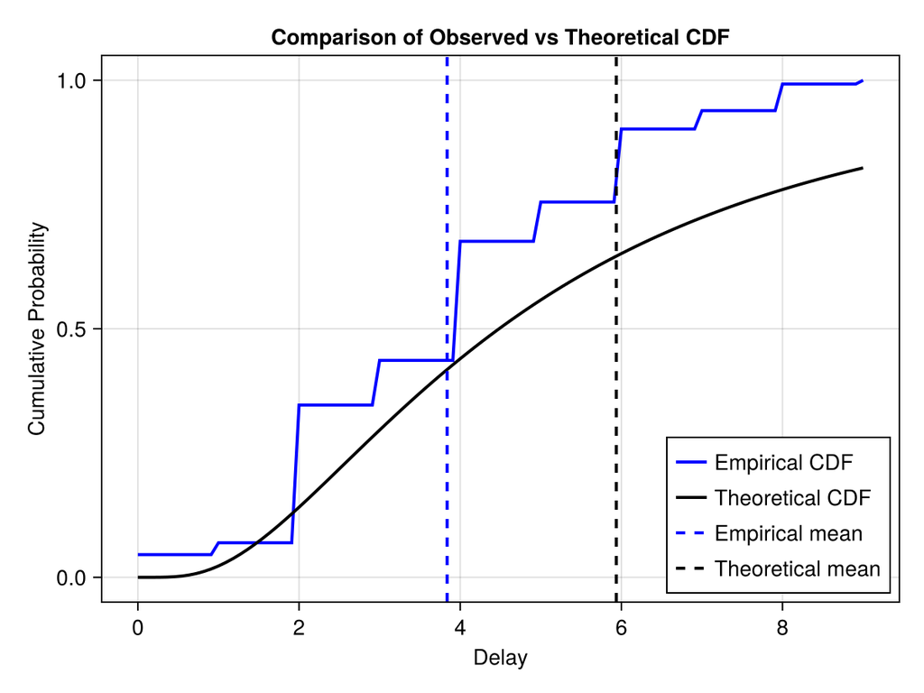

```julia
let
    f = Figure()
    ax = Axis(f[1, 1],
        title = "Comparison of Observed vs Theoretical CDF",
        ylabel = "Cumulative Probability",
        xlabel = "Delay"
    )
    lines!(
        ax, x_seq, empirical_cdf_obs, label = "Empirical CDF", color = :blue, linewidth = 2)
    lines!(ax, x_seq, theoretical_cdf, label = "Theoretical CDF",
        color = :black, linewidth = 2)
    vlines!(ax, [mean(samples)], color = :blue, linestyle = :dash,
        label = "Empirical mean", linewidth = 2)
    vlines!(ax, [mean(true_dist)], linestyle = :dash,
        label = "Theoretical mean", color = :black, linewidth = 2)
    axislegend(position = :rb)

    f
end
```

We've aggregated the data to unique combinations of `pwindow`, `swindow`, and `obs_time` and counted the number of occurrences of each `observed_delay` for each combination. This is the data we will use to fit our model.

## Fitting a naive model using Turing

We'll start by fitting a naive model using NUTS from `Turing`. We define the model in the `Turing` PPL.

```julia
@model function naive_model(N, y, n)
    mu ~ Normal(1.0, 1.0)
    sigma ~ truncated(Normal(0.5, 1.0); lower = 0.0)
    d = LogNormal(mu, sigma)

    for i in eachindex(y)
        Turing.@addlogprob! n[i] * logpdf(d, y[i])
    end
end
```

```
naive_model (generic function with 2 methods)
```

Now lets instantiate this model with data

```julia
naive_mdl = naive_model(
    size(delay_counts, 1),
    delay_counts.observed_delay .+ 1e-6, # Add a small constant to avoid log(0)
    delay_counts.n)
```

```
DynamicPPL.Model{typeof(naive_model), (:N, :y, :n), (), (), Tuple{Int64, Vector{Float64}, Vector{Int64}}, Tuple{}, DynamicPPL.DefaultContext}(naive_model, (N = 80, y = [1.0e-6, 1.000001, 2.000001, 3.000001, 4.000001, 5.000001, 6.000001, 7.000001, 1.0e-6, 1.000001  …  1.0e-6, 2.000001, 4.000001, 6.000001, 8.000001, 1.0e-6, 2.000001, 4.000001, 6.000001, 8.000001], n = [1, 13, 32, 29, 34, 26, 19, 14, 2, 5  …  13, 69, 59, 30, 12, 9, 69, 48, 29, 22]), NamedTuple(), DynamicPPL.DefaultContext())
```

and now let's fit the compiled model.

```julia
naive_fit = sample(naive_mdl, NUTS(), MCMCThreads(), 500, 4)
```

|  | iteration | chain | mu | sigma | lp | n_steps | is_accept | acceptance_rate | ... |
| --- | --- | --- | --- | --- | --- | --- | --- | --- | --- |
| 1 | 251 | 1 | 0.569828 | 3.16687 | -6326.42 | 3.0 | 1.0 | 0.889234 |  |
| 2 | 252 | 1 | 0.51554 | 3.21602 | -6327.17 | 3.0 | 1.0 | 0.748919 |  |
| 3 | 253 | 1 | 0.699124 | 3.15787 | -6327.72 | 7.0 | 1.0 | 0.895135 |  |
| 4 | 254 | 1 | 0.523035 | 3.16482 | -6326.8 | 3.0 | 1.0 | 0.728358 |  |
| 5 | 255 | 1 | 0.497583 | 3.17839 | -6327.16 | 3.0 | 1.0 | 0.840027 |  |
| 6 | 256 | 1 | 0.548956 | 3.15474 | -6326.61 | 3.0 | 1.0 | 0.792753 |  |
| 7 | 257 | 1 | 0.569335 | 3.16453 | -6326.43 | 3.0 | 1.0 | 1.0 |  |
| 8 | 258 | 1 | 0.606234 | 3.2018 | -6326.53 | 3.0 | 1.0 | 0.977859 |  |
| 9 | 259 | 1 | 0.530658 | 3.17006 | -6326.69 | 3.0 | 1.0 | 0.900204 |  |
| 10 | 260 | 1 | 0.627117 | 3.11173 | -6327.41 | 7.0 | 1.0 | 0.761508 |  |
| ... |  |  |  |  |  |  |  |  |  |

```julia
summarize(naive_fit)
```

|  | parameters | mean | std | mcse | ess_bulk | ess_tail | rhat | ess_per_sec |
| --- | --- | --- | --- | --- | --- | --- | --- | --- |
| 1 | :mu | 0.584129 | 0.0704067 | 0.00151449 | 2153.02 | 1487.54 | 1.00003 | 244.94 |
| 2 | :sigma | 3.17766 | 0.0495775 | 0.00113542 | 1905.04 | 1306.94 | 1.00127 | 216.728 |

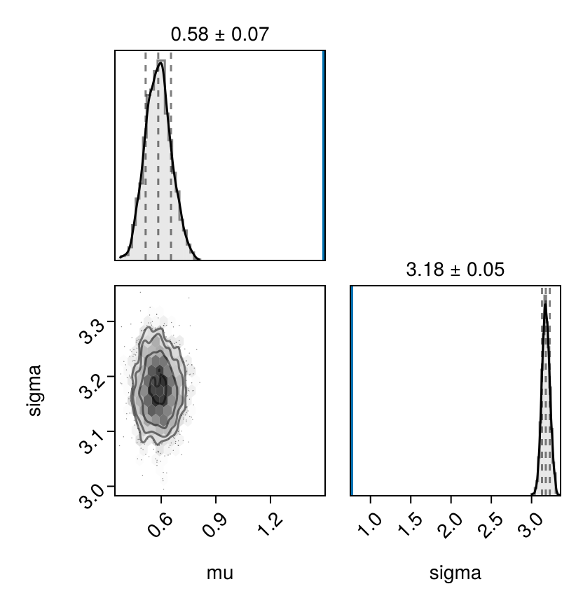

```julia
let
    f = pairplot(naive_fit)
    vlines!(f[1, 1], [meanlog], linewidth = 4)
    vlines!(f[2, 2], [sdlog], linewidth = 4)
    f
end
```

We see that the model has converged and the diagnostics look good. However, just from the model posterior summary we see that we might not be very happy with the fit. `mu` is smaller than the target 1.5 and `sigma` is larger than the target 0.75.

## Fitting an improved model using censoring utilities

We'll now fit an improved model using the `∫F` function from `EpiAware.EpiAwareUtils` for calculating the CDF of the *total delay* from the beginning of the primary window to the secondary event time. This includes both the delay distribution we are making inference on and the time between the start of the primary censor window and the primary event. The `∫F` function underlies `censored_pmf` function from the `EpiAware.EpiAwareUtils` submodule.

Using the `∫F` function we can write a log-pmf function `primary_censored_dist_lpmf` that accounts for:

- The primary and secondary censoring windows, which can vary in length.
- The effect of right truncation in biasing our observations.

This is the analog function to the function of the same name in `primarycensoreddist`: it calculates the log-probability of the secondary event occurring in the secondary censoring window conditional on the primary event occurring in the primary censoring window by calculating the increase in the CDF over the secondary window and rescaling by the probability of the secondary event occuring within the maximum observation time `D`.

```julia
function primary_censored_dist_lpmf(dist, y, pwindow, y_upper, D)
    if y == 0.0
        return log(∫F(dist, y_upper, pwindow)) - log(∫F(dist, D, pwindow))
    else
        return log(∫F(dist, y_upper, pwindow) - ∫F(dist, y, pwindow)) -
               log(∫F(dist, D, pwindow))
    end
end
```

```
primary_censored_dist_lpmf (generic function with 1 method)
```

We make a new `Turing` model that now uses `primary_censored_dist_lpmf` rather than the naive uncensored and untruncated `logpdf`.

```julia
@model function primarycensoreddist_model(y, y_upper, n, pws, Ds)
    mu ~ Normal(1.0, 1.0)
    sigma ~ truncated(Normal(0.5, 0.5); lower = 0.0)
    dist = LogNormal(mu, sigma)

    for i in eachindex(y)
        Turing.@addlogprob! n[i] * primary_censored_dist_lpmf(
            dist, y[i], pws[i], y_upper[i], Ds[i])
    end
end
```

```
primarycensoreddist_model (generic function with 2 methods)
```

Lets instantiate this model with data

```julia
primarycensoreddist_mdl = primarycensoreddist_model(
    delay_counts.observed_delay,
    delay_counts.observed_delay_upper,
    delay_counts.n,
    delay_counts.pwindow,
    delay_counts.obs_time
)
```

```
DynamicPPL.Model{typeof(primarycensoreddist_model), (:y, :y_upper, :n, :pws, :Ds), (), (), Tuple{Vector{Float64}, Vector{Float64}, Vector{Int64}, Vector{Int64}, Vector{Int64}}, Tuple{}, DynamicPPL.DefaultContext}(primarycensoreddist_model, (y = [0.0, 1.0, 2.0, 3.0, 4.0, 5.0, 6.0, 7.0, 0.0, 1.0  …  0.0, 2.0, 4.0, 6.0, 8.0, 0.0, 2.0, 4.0, 6.0, 8.0], y_upper = [1.0, 2.0, 3.0, 4.0, 5.0, 6.0, 7.0, 8.0, 1.0, 2.0  …  2.0, 4.0, 6.0, 8.0, 10.0, 2.0, 4.0, 6.0, 8.0, 10.0], n = [1, 13, 32, 29, 34, 26, 19, 14, 2, 5  …  13, 69, 59, 30, 12, 9, 69, 48, 29, 22], pws = [1, 1, 1, 1, 1, 1, 1, 1, 1, 1  …  2, 2, 2, 2, 2, 2, 2, 2, 2, 2], Ds = [8, 8, 8, 8, 8, 8, 8, 8, 9, 9  …  9, 9, 9, 9, 9, 10, 10, 10, 10, 10]), NamedTuple(), DynamicPPL.DefaultContext())
```

Now let’s fit the compiled model.

```julia
primarycensoreddist_fit = sample(
    primarycensoreddist_mdl, NUTS(), MCMCThreads(), 1000, 4)
```

|  | iteration | chain | mu | sigma | lp | n_steps | is_accept | acceptance_rate | ... |
| --- | --- | --- | --- | --- | --- | --- | --- | --- | --- |
| 1 | 501 | 1 | 1.46819 | 0.771804 | -3376.41 | 3.0 | 1.0 | 1.0 |  |
| 2 | 502 | 1 | 1.46877 | 0.738944 | -3375.1 | 3.0 | 1.0 | 0.999202 |  |
| 3 | 503 | 1 | 1.49735 | 0.740651 | -3376.39 | 3.0 | 1.0 | 0.741842 |  |
| 4 | 504 | 1 | 1.47618 | 0.762895 | -3375.61 | 3.0 | 1.0 | 0.983406 |  |
| 5 | 505 | 1 | 1.48132 | 0.74067 | -3375.47 | 3.0 | 1.0 | 0.852127 |  |
| 6 | 506 | 1 | 1.40746 | 0.711968 | -3375.63 | 7.0 | 1.0 | 0.914995 |  |
| 7 | 507 | 1 | 1.44329 | 0.747661 | -3375.55 | 7.0 | 1.0 | 0.89498 |  |
| 8 | 508 | 1 | 1.43568 | 0.734698 | -3375.17 | 3.0 | 1.0 | 0.977821 |  |
| 9 | 509 | 1 | 1.42456 | 0.696408 | -3375.79 | 3.0 | 1.0 | 0.941795 |  |
| 10 | 510 | 1 | 1.46966 | 0.758485 | -3375.46 | 5.0 | 1.0 | 1.0 |  |
| ... |  |  |  |  |  |  |  |  |  |

```julia
summarize(primarycensoreddist_fit)
```

|  | parameters | mean | std | mcse | ess_bulk | ess_tail | rhat | ess_per_sec |
| --- | --- | --- | --- | --- | --- | --- | --- | --- |
| 1 | :mu | 1.45168 | 0.0355514 | 0.00108636 | 1087.88 | 1420.31 | 1.00169 | 49.8275 |
| 2 | :sigma | 0.733008 | 0.0274925 | 0.00082729 | 1110.27 | 1643.86 | 1.00173 | 50.8527 |

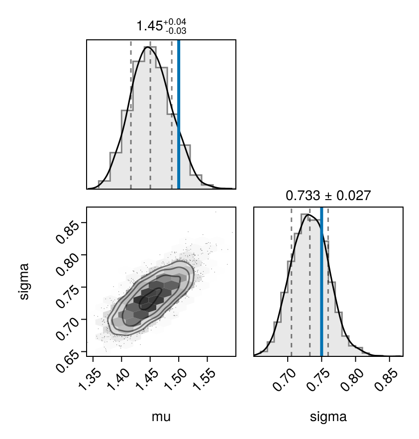

```julia
let
    f = pairplot(primarycensoreddist_fit)
    CairoMakie.vlines!(f[1, 1], [meanlog], linewidth = 3)
    CairoMakie.vlines!(f[2, 2], [sdlog], linewidth = 3)
    f
end
```